# Impact of Possession Initiation on Efficient Field Goal Percent.

- Show All Code
- Hide All Code
- View Source

Author

Louis BT

Published

December 14, 2024

### Introduction

In this report, an analysis of how a possession is initiated for an offensive team affects their efficient field goal percent is done. A distinction is made between five types of possession initiation:

1. ‘make’ - the opposing team made their shot attempt. The referee does not have to give the ball to the player inbounding.
2. ‘miss’ - the opposing team missed their shot attempt
3. ‘live_tov’ - the opposing team lost possession of the ball, but the ball remains in play. (i.e. a steal, etc..)
4. ‘dead_ball’ - the ball is inbounded from out of bounds, this includes out of timeout possessions, or offensive fouls. The referee has to give the ball the player inbounding the ball.
5. ‘oreb’ - the offensive team gets an offensive rebound and continues their offensive possesion.

The reasoning for these five unique plays is because the defensive team has different levels of readiness for a play to occur. In a ‘live_tov’, the defense is typically behind the play. In an offensive rebound situation, the defense may be scrambling and the offensive team may find a favourable matchup. In a ‘dead_ball’ situation, the defense set up but the offensive team may have a more elaborate play to run. The goal is to find how different possession types can lead to different success rates.

**Code: Setup**

```r
library(tidyverse)
library(ggplot2)
library(emmeans)
library(gridExtra)
library(kableExtra)

`%notin%` <- Negate(`%in%`)

pbpdata = read.csv('2024pbpclean.csv')
pbpdata[is.na(pbpdata)] = 0
pbpdata$shot_off = NA
```

**Code: Data manipulation**

```r
pbpdata = pbpdata %>%
  mutate(
    shot_off = case_when(
      row_number() == 1 ~ 'dead_ball',
      lag(event_type) %in% c('shot_made', 'free_throw_made') ~ 'make',
      lag(event_type) %in% c('shot_missed', 'free_throw_miss') ~ 'miss',
      lag(event_type) == 'off_rebound' ~ 'oreb',
      lag(event_type) == 'turnover' ~ ifelse(lag(stl_by) == '', 'dead_tov', 'live_tov'),
      lag(event_type) == 'def_rebound' ~ lag(shot_off),
      lag(event_type) == 'unknowntype1' ~ 'dead_ball',
      lag(event_type) == 'foul' ~ 'dead_ball',
      TRUE ~ NA_character_
    )
    ) %>% fill(shot_off, .direction = 'down') %>%
  mutate(
    shot_off = case_when(
      event_type %in% c('unknowntype1', 'substitution', 'foul') ~ NA_character_,
      TRUE ~ shot_off
    )
  )

pbpdf  = pbpdata %>%
  select(team, shot_off, `X2fgm`, `X2fga`, `X3fgm`, `X3fga`) %>%
  mutate(
    across(
      .cols = c(`X2fgm`, `X2fga`, `X3fgm`, `X3fga`),
      .fns = ~ ifelse(is.na(.), 0, .)
    )
  ) %>% group_by(team) %>%
  mutate(
    shot_off = ifelse( shot_off %in% c('dead_tov', 'dead_ball'), 'dead_ball', shot_off)
  ) %>% group_by(team, shot_off) %>%
  summarise(across(where(is.numeric), sum), .groups = 'drop') %>%
  filter(!is.na(shot_off)) %>%
  mutate(
    efg = (`X2fgm` + 1.5*`X3fgm`) / (`X2fga`+`X3fga`)
  ) %>% select(team, shot_off, efg)

#view(pbpdf)
```

### Assumption Checking

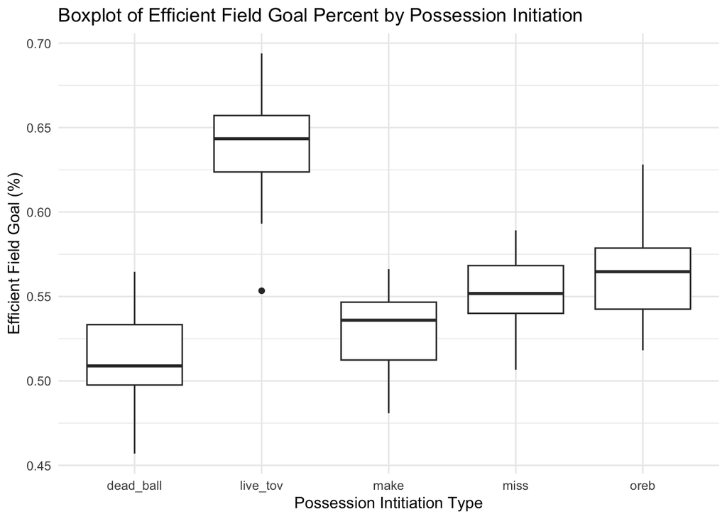

```r
ggplot(pbpdf) +
  aes(x = shot_off, y = efg) +
  geom_boxplot() +
  labs(
    title = "Boxplot of Efficient Field Goal Percent by Possession Initiation",
    y = 'Efficient Field Goal (%)',
    x = 'Possession Intitiation Type'
  ) +
  theme_minimal()
```

```r
pbpdf %>% select(!team) %>%
  mutate(efg = 100*efg) %>%
  rename("Possession Type" = shot_off) %>% group_by(`Possession Type`) %>%
  summarise("Variance of EFG%" = var(efg)) %>% ungroup() %>%
  kbl(caption = "Variance of EFG% by Possession Type") %>% kable_styling()
```

Variance of EFG% by Possession Type

| Possession Type | Variance of EFG% |
| --- | --- |
| dead_ball | 7.257579 |
| live_tov | 8.696005 |
| make | 5.056506 |
| miss | 3.884539 |
| oreb | 7.261015 |

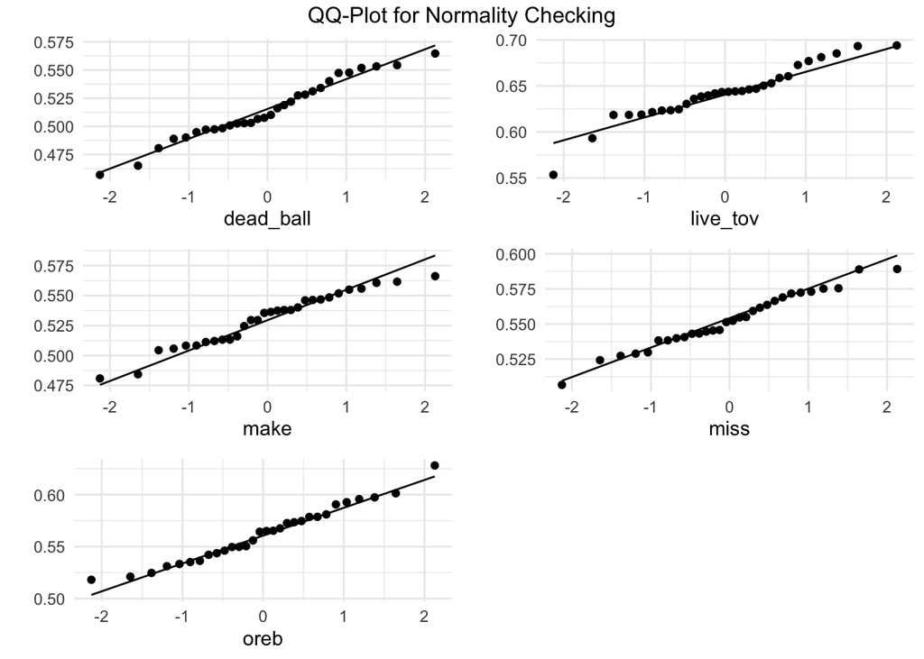

```r
p1 = pbpdf %>% filter(shot_off == 'dead_ball') %>%  ggplot(aes(sample = efg)) + geom_qq() + geom_qq_line() + theme_minimal() + labs(y = '', x = 'dead_ball')
p2 = pbpdf %>% filter(shot_off == 'live_tov') %>% ggplot(aes(sample = efg)) + geom_qq() + geom_qq_line() + theme_minimal() + labs(y = '', x = 'live_tov')
p3 = pbpdf %>% filter(shot_off == 'make') %>% ggplot(aes(sample = efg)) + geom_qq() + geom_qq_line() + theme_minimal() + labs(y = '', x = 'make')
p4 = pbpdf %>% filter(shot_off == 'miss') %>% ggplot(aes(sample = efg)) + geom_qq() + geom_qq_line() + theme_minimal() + labs(y = '', x = 'miss')
p5 = pbpdf %>% filter(shot_off == 'oreb') %>% ggplot(aes(sample = efg)) + geom_qq() + geom_qq_line() + theme_minimal() + labs(y = '', x = 'oreb')

grid.arrange(p1, p2, p3, p4, p5,
             top = 'QQ-Plot for Normality Checking',
             ncol = 2)
```

### ANOVA

```r
fit = aov(efg ~ shot_off + team, data = pbpdf)
fit_emmeans = emmeans(fit, ~ shot_off)
# contrast(fit_emmeans, method = 'pairwise', adjust = 'bonferroni', pool.sd = FALSE)
# contrast(fit_emmeans, method = 'pairwise', adjust = 'scheffe') %>% confint()
# contrast(fit_emmeans, method = 'pairwise', adjust = 'tukey', pool.sd = FALSE) %>% confint()

contrast(fit_emmeans, method = 'pairwise', adjust = 'tukey', pool.sd = FALSE) %>% kbl(caption = "ANOVA using Tukey Post-Hoc test") %>% kable_styling()
```

ANOVA using Tukey Post-Hoc test

| contrast | estimate | SE | df | t.ratio | p.value |
| --- | --- | --- | --- | --- | --- |
| dead_ball - live_tov | -0.1278208 | 0.0049835 | 116 | -25.648789 | 0.0000000 |
| dead_ball - make | -0.0155184 | 0.0049835 | 116 | -3.113961 | 0.0193417 |
| dead_ball - miss | -0.0378176 | 0.0049835 | 116 | -7.588560 | 0.0000000 |
| dead_ball - oreb | -0.0475039 | 0.0049835 | 116 | -9.532233 | 0.0000000 |
| live_tov - make | 0.1123024 | 0.0049835 | 116 | 22.534828 | 0.0000000 |
| live_tov - miss | 0.0900032 | 0.0049835 | 116 | 18.060229 | 0.0000000 |
| live_tov - oreb | 0.0803169 | 0.0049835 | 116 | 16.116556 | 0.0000000 |
| make - miss | -0.0222992 | 0.0049835 | 116 | -4.474600 | 0.0001727 |
| make - oreb | -0.0319855 | 0.0049835 | 116 | -6.418272 | 0.0000000 |
| miss - oreb | -0.0096863 | 0.0049835 | 116 | -1.943673 | 0.3004451 |

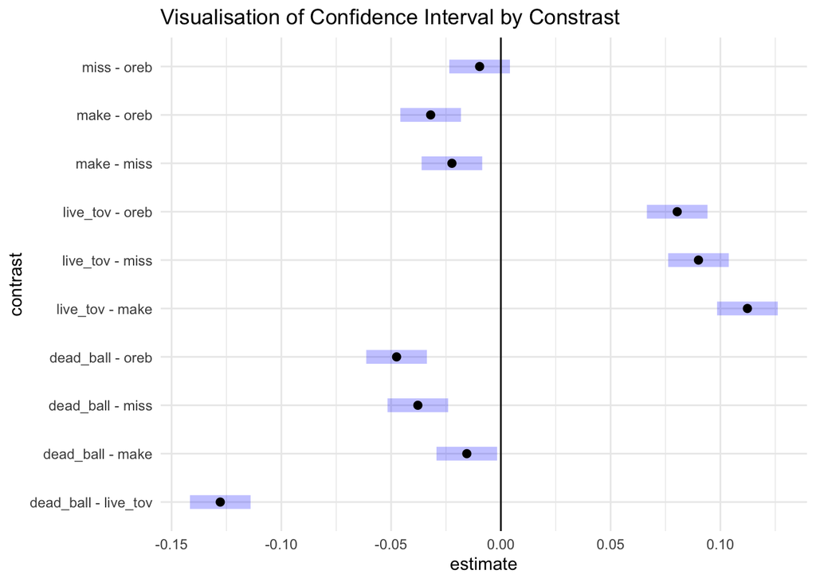

```r
contrast(fit_emmeans, method = 'pairwise', adjust = 'tukey', pool.sd = FALSE) %>% plot() + geom_vline(xintercept = 0) + theme_minimal() + labs(title = "Visualisation of Confidence Interval by Constrast")
```